# Innovando la Contratación Pública con Inteligencia Artificial

TIAckathon 2023

Author

Bryan Jair Aragón Pilco

Published

September 25, 2023

# 1 INTRODUCCIÓN

Las Contrataciones Abiertas permiten mejorar la divulgación, calidad y uso de los datos de compras públicas en todas las fases del procedimiento mediante la implementación del Estándar de Datos para las Contrataciones Abiertas - EDCA (OCDS).

El presente trabajo pretende centrar a la Contratación Pública como herramienta fundamental para tomar decisiones de Política Monetaria, su importancia radica en la gran cantidad de dinero que es destinada año a año a los procesos de Compras Públicas. Esta importante suma de dinero tiene como finalidad dinamizar el trabajo a través de los distintos proveedores, es decir, la eficiencia y el buen manejo del dinero hacia el destinatario final mejorará la economía del país, puesto que, el proveedor, contratista, consultor o cualquier persona que le venda sus servicios, obras y bienes al estado, pondrá a trabajar el dinero obtenido, dando empleo, adquiriendo suministros o cualquier materia prima que le permita cumplir con el objeto de contratación.

*URL:* [Repositorio GITHub](https://github.com/BJAP3-1415/IA_CP)

**Note**

El presente análisis se realiza mediante el lenguaje R y se presenta en formato QUARTO. Palabras claves: Liquidez M2, Gastos del Sector Público, Ingresos tributarios, Oferta Monetaria, Política Económica.

# 2 LIBRERÍAS UTILIZADAS

```r
library(tidyverse)
library(openxlsx)
library(lubridate)
library(readxl)
library(corrplot)
library(tidymodels)
library(GGally)
library(randomForest)
library(paletteer)
```

# 3 DATA

Table 1: Variables utilizadas

| Descripción | Siglas | Unidad | Tipo |
| --- | --- | --- | --- |
| Liquidez Total | M2 | num | Independiente |
| Ingresos Tributarios | Ingr_trib | num | Independiente |
| Gastos del Sector Público | Gast_SPF | num | Independiente |
| Oferta Monetaria | Ofert_M1 | num | Independiente |
| Contratación Pública | CP | num | Dependiente |

## 3.1 Data OCDS

Los datos se extraen de la siguiente página: [DataOCD](https://datosabiertos.compraspublicas.gob.ec/PLATAFORMA)

> **Data OCDS, correspondiente al total del monto adjudicado del año 2023.**

```r
dataA1 <- read.csv('awards_2023.csv')
dataA1 <- as.data.frame(dataA1) %>%
  select(c(date, amount)) %>%
  drop_na() %>%
  mutate(date= ymd_hms(date)) %>%
  mutate(mes = month(date))

dataA2 <- dataA1 %>%
  select(c(amount, mes)) %>%
  mutate_all(~coalesce(.,8)) %>%
  group_by(mes)%>%
  summarise(amount= sum(amount)) %>%
  slice(-c( 9))

paste('El monto total de Contratación pública al 2023 representa la cantidad de:',sum(dataA2$amount), 'usd.')
```

```
[1] "El monto total de Contratación pública al 2023 representa la cantidad de: 2810144175.2 usd."
```

> **Data OCDS, correspondiente al total del monto adjudicado del año 2022.**

```r
dataB1 <- read.csv('awards_2022.csv')
dataB1 <- as.data.frame(dataB1) %>%
  select(c(date, amount)) %>%
  drop_na() %>%
  mutate(date= ymd_hms(date)) %>%
  mutate(mes = month(date))

dataB2 <- dataB1 %>%
  select(c(amount, mes)) %>%
  mutate_all(~coalesce(.,12)) %>%
  group_by(mes)%>%
  summarise(amount= sum(amount))


paste('El monto total de Contratación pública del año 2022 representa la cantidad de:',sum(dataB2$amount), 'usd.')
```

```
[1] "El monto total de Contratación pública del año 2022 representa la cantidad de: 6794800700.02 usd."
```

> **Data OCDS, correspondiente al total del monto adjudicado del año 2021.**

```r
dataC1 <- read.csv('awards_2021.csv')
dataC1 <- as.data.frame(dataC1) %>%
  select(c(date, amount)) %>%
  drop_na() %>%
  mutate(date= ymd_hms(date)) %>%
  mutate(mes = month(date))

dataC2 <- dataC1 %>%
  select(c(amount, mes)) %>%
  mutate_all(~coalesce(.,12)) %>%
  group_by(mes)%>%
  summarise(amount= sum(amount))

paste('El monto total de Contratación pública del año 2021 representa la cantidad de:',sum(dataC2$amount), 'usd.')
```

```
[1] "El monto total de Contratación pública del año 2021 representa la cantidad de: 4676997257.82 usd."
```

> **Data OCDS, correspondiente al total del monto adjudicado del año 2020.**

```r
dataD1 <- read.csv('awards_2020.csv')
dataD1 <- as.data.frame(dataD1) %>%
  select(c(date, amount)) %>%
  drop_na() %>%
  mutate(date= ymd_hms(date)) %>%
  mutate(mes = month(date))

dataD2 <- dataD1 %>%
  select(c(amount, mes)) %>%
  mutate_all(~coalesce(.,12)) %>%
  group_by(mes)%>%
  summarise(amount= sum(amount))

paste('El monto total de Contratación pública del año 2020 representa la cantidad de:',sum(dataD2$amount), 'usd.')
```

```
[1] "El monto total de Contratación pública del año 2020 representa la cantidad de: 3858050268.61 usd."
```

> **Data OCDS, correspondiente al total del monto adjudicado del año 2019.**

```r
dataE1 <- read.csv('awards_2019.csv')
dataE1 <- as.data.frame(dataE1) %>%
  select(c(date, amount)) %>%
  drop_na() %>%
  mutate(date= ymd_hms(date)) %>%
  mutate(mes = month(date))

dataE2 <- dataE1 %>%
  select(c(amount, mes)) %>%
  mutate_all(~coalesce(.,12)) %>%
  group_by(mes)%>%
  summarise(amount= sum(amount))

paste('El monto total de Contratación pública del año 2019 representa la cantidad de:',sum(dataE2$amount), 'usd.')
```

```
[1] "El monto total de Contratación pública del año 2019 representa la cantidad de: 5163524864.54 usd."
```

> **Data OCDS, correspondiente al total del monto adjudicado del año 2018.**

```r
dataF1 <- read.csv('awards_2018.csv')
dataF1 <- as.data.frame(dataF1) %>%
  select(c(date, amount)) %>%
  drop_na() %>%
  mutate(date= ymd_hms(date)) %>%
  mutate(mes = month(date))

dataF2 <- dataF1 %>%
  select(c(amount, mes)) %>%
  mutate_all(~coalesce(.,12)) %>%
  group_by(mes)%>%
  summarise(amount= sum(amount))

paste('El monto total de Contratación pública del año 2018 representa la cantidad de:',sum(dataF2$amount), 'usd.')
```

```
[1] "El monto total de Contratación pública del año 2018 representa la cantidad de: 6313959328.78 usd."
```

> **Data OCDS, correspondiente al total del monto adjudicado del año 2017.**

```r
dataG1 <- read.csv('awards_2017.csv')
dataG1 <- as.data.frame(dataG1) %>%
  select(c(date, amount)) %>%
  drop_na() %>%
  mutate(date= ymd_hms(date)) %>%
  mutate(mes = month(date))

dataG2 <- dataG1 %>%
  select(c(amount, mes)) %>%
  mutate_all(~coalesce(.,12)) %>%
  group_by(mes)%>%
  summarise(amount= sum(amount))

paste('El monto total de Contratación pública del año 2017 representa la cantidad de:',sum(dataG2$amount), 'usd.')
```

```
[1] "El monto total de Contratación pública del año 2017 representa la cantidad de: 5255102657.9 usd."
```

> **Data OCDS, correspondiente al total del monto adjudicado del año 2016.**

```r
dataH1 <- read.csv('awards_2016.csv')
dataH1 <- as.data.frame(dataH1) %>%
  select(c(date, amount)) %>%
  drop_na() %>%
  mutate(date= ymd_hms(date)) %>%
  mutate(mes = month(date))

dataH2 <- dataH1 %>%
  select(c(amount, mes)) %>%
  mutate_all(~coalesce(.,12)) %>%
  group_by(mes)%>%
  summarise(amount= sum(amount))

paste('El monto total de Contratación pública del año 2016 representa la cantidad de:',sum(dataH2$amount), 'usd.')
```

```
[1] "El monto total de Contratación pública del año 2016 representa la cantidad de: 4696961004.38 usd."
```

> **Data OCDS, correspondiente al total del monto adjudicado del año 2015.**

```r
dataI1 <- read.csv('awards_2015.csv')
dataI1 <- as.data.frame(dataI1) %>%
  select(c(date, amount)) %>%
  drop_na() %>%
  mutate(date= ymd_hms(date)) %>%
  mutate(mes = month(date))

dataI2 <- dataI1 %>%
  select(c(amount, mes)) %>%
  mutate_all(~coalesce(.,12)) %>%
  group_by(mes)%>%
  summarise(amount= sum(amount))

paste('El monto total de Contratación pública del año 2015 representa la cantidad de:',sum(dataI2$amount), 'usd.')
```

```
[1] "El monto total de Contratación pública del año 2015 representa la cantidad de: 5997696058.51 usd."
```

## 3.2 Data de Variables-Predictoras

```r
Data <- read_excel("Data.xlsx")

Data %>%
  slice_head(n = 5)
```

```
# A tibble: 5 × 5
  date                         m2   Ingr_trib    Gast_SPF    Ofert_M1
  <dttm>                    <dbl>       <dbl>       <dbl>       <dbl>
1 2015-01-01 00:00:00 39113998008 1538708691. 2346854931. 18052328008
2 2015-02-01 00:00:00 39058055359 1094217003. 3246543749. 17847905359
3 2015-03-01 00:00:00 39560879416 1239747228. 3697877166. 18282969416
4 2015-04-01 00:00:00 39549086051 1972151249. 3185393168. 18172626051
5 2015-05-01 00:00:00 39566676736 1208172259. 3691454351. 18157936736
```

## 3.3 Data Compilada

```r
años <- rep(2015:2022, each = 12)
meses <- rep(1:12, times = 8)
meses2023 <- rep(1:8, times =1)
cantidad <- rbind(dataI2,dataH2,dataG2,dataF2,dataE2,dataD2,dataC2,dataB2) %>%
  select(amount)
# Creamos el dataframe
df <- data.frame(Fecha = as.Date(paste(años, meses, "01", sep = "-"), format = "%Y-%m-%d"),cantidad = cantidad)

dataA2 <- data.frame(Fecha = as.Date(paste(2023, meses2023, "01", sep = "-"), format = "%Y-%m-%d"),cantidad =dataA2[2] )

df <- rbind(df, dataA2)

dataX <- cbind.data.frame(Data, CP=df$amount)

dataX %>%
  slice_head(n=5)
```

```
        date          m2  Ingr_trib   Gast_SPF    Ofert_M1        CP
1 2015-01-01 39113998008 1538708691 2346854931 18052328008 347850631
2 2015-02-01 39058055359 1094217003 3246543749 17847905359 193761873
3 2015-03-01 39560879416 1239747228 3697877166 18282969416 312681954
4 2015-04-01 39549086051 1972151249 3185393168 18172626051 478483890
5 2015-05-01 39566676736 1208172259 3691454351 18157936736 362359363
```

```r
summary(dataX)
```

```
      date                              m2              Ingr_trib
 Min.   :2015-01-01 00:00:00.00   Min.   :3.884e+10   Min.   :7.464e+08
 1st Qu.:2017-02-22 00:00:00.00   1st Qu.:4.685e+10   1st Qu.:1.087e+09
 Median :2019-04-16 00:00:00.00   Median :5.401e+10   Median :1.153e+09
 Mean   :2019-04-16 22:09:13.84   Mean   :5.577e+10   Mean   :1.209e+09
 3rd Qu.:2021-06-08 12:00:00.00   3rd Qu.:6.522e+10   3rd Qu.:1.258e+09
 Max.   :2023-08-01 00:00:00.00   Max.   :7.677e+10   Max.   :2.052e+09
    Gast_SPF            Ofert_M1               CP
 Min.   :2.347e+09   Min.   :1.785e+10   Min.   :3.508e+06
 1st Qu.:3.157e+09   1st Qu.:2.269e+10   1st Qu.:2.662e+08
 Median :3.409e+09   Median :2.491e+10   Median :3.233e+08
 Mean   :3.543e+09   Mean   :2.495e+10   Mean   :4.381e+08
 3rd Qu.:3.660e+09   3rd Qu.:2.844e+10   3rd Qu.:4.174e+08
 Max.   :6.576e+09   Max.   :3.079e+10   Max.   :2.333e+09
```

# 4 EDA.

- Histograma por cada característica, representando su media y mediana

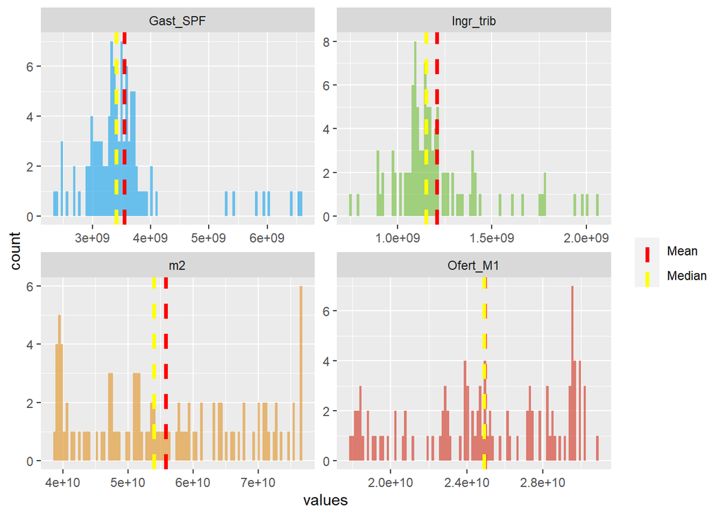

```r
# Create a data frame of numeric features & label
numeric_features <- dataX %>%
  select(c(m2, Ingr_trib, Gast_SPF, Ofert_M1, CP))

# Pivot data to a long format
numeric_features <- numeric_features %>%
  pivot_longer(!CP,names_to = "features", values_to = "values") %>%
  group_by(features) %>%
  mutate(Mean = mean(values),
         Median = median(values))


# Plot a histogram for each feature
numeric_features %>%
  ggplot() +
  geom_histogram(aes(x = values, fill = features), bins = 100, alpha = 0.7, show.legend = F) +
  facet_wrap(~ features, scales = 'free')+
  paletteer::scale_fill_paletteer_d("ggthemes::excel_Parallax") +

  # Add lines for mean and median
  geom_vline(aes(xintercept = Mean, color = "Mean"), linetype = "dashed", size = 1.3 ) +
  geom_vline(aes(xintercept = Median, color = "Median"), linetype = "dashed", size = 1.3 ) +
  scale_color_manual(name = "", values = c(Mean = "red", Median = "yellow"))
```

- Con los datos normalizados es fácil ver una aparente relación entre variables. No indica un emparejamiento exacto, pero se ve claramente que el valor más alto de la contratación pública durante el periodo de análisis coincide con los montos más altos de las variables predictoras.

```r
dataZ<- as.data.frame(dataX) %>%
  mutate(Year = year(date))

dataZ_2 <- dataZ %>%
  group_by(Year)%>%
  summarise(CP= sum(CP), m2=sum(m2), Ingr_trib= sum(Ingr_trib), Gast_SPF=sum(Gast_SPF), Ofert_M1=sum(Ofert_M1))

# Pivot data from wide to long
df_sample_long <- dataZ_2 %>%
  pivot_longer(!Year, names_to = "Metrics", values_to = "Values")

# Normalize the numeric columns
df_normalized <- df_sample_long %>%
  group_by(Metrics) %>%
  mutate(Values = rescale(Values, to = c(0, 1)))

# Show some of the normalized data
df_normalized %>%
  slice_head(n = 5)
```

```
# A tibble: 25 × 3
# Groups:   Metrics [5]
    Year Metrics  Values
   <dbl> <chr>     <dbl>
 1  2015 CP        0.800
 2  2016 CP        0.474
 3  2017 CP        0.614
 4  2018 CP        0.879
 5  2019 CP        0.591
 6  2015 Gast_SPF  0.858
 7  2016 Gast_SPF  0.874
 8  2017 Gast_SPF  0.825
 9  2018 Gast_SPF  0.928
10  2019 Gast_SPF  0.853
# … with 15 more rows
```

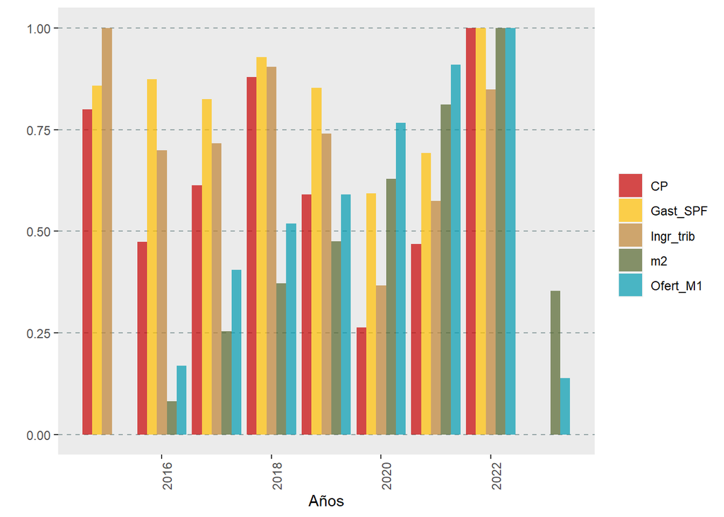

```r
# Comparación de variables mediante un bar plot
ggplot(data = df_normalized) +
  geom_bar(mapping = aes(x = Year, y = Values, fill = Metrics), alpha = 0.7, stat = "identity", position = position_dodge(width = 0.9)) +
  xlab('Años') +
  ylab('') +
  scale_fill_paletteer_d("calecopal::kelp1") +
  theme(
    panel.grid = element_blank(),
    panel.grid.major.y = element_line(color = '#95a5a6',
                                      linetype = 'dashed',
                                      size = 0.5),
    axis.text.x = element_text(angle = 90),
    legend.title = element_blank()
  )
```

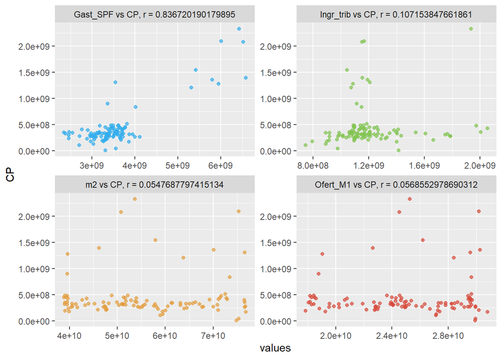

```r
# Plot a scatter plot for each feature
numeric_features %>%
  mutate(corr_coef = cor(values, CP)) %>%
  mutate(features = paste(features, ' vs CP, r = ', corr_coef, sep = '')) %>%
  ggplot(aes(x = values, y = CP, color = features)) +
  geom_point(alpha = 0.7, show.legend = F) +
  facet_wrap(~ features, scales = 'free')+
  paletteer::scale_color_paletteer_d("ggthemes::excel_Parallax")
```

# 5 MODELOS

```r
# Seleccionamos las caracterisitcas y etiquetas deseadas
dataSelect <- dataX %>%
  select(c(m2, Ingr_trib, Gast_SPF, Ofert_M1, CP))

# Dividimos 80% de los datos para training y el resto para testing
set.seed(2056)
data_split <- dataSelect %>%
  initial_split(prop = 0.8, strata = CP)

# Extracción de los datos
dataTrain <- training(data_split)
dataTest <- testing(data_split)

# Especificamos algunas metricas de regresión

eval_metric <- metric_set(rmse, rsq)

cat("Training Set", nrow(dataTrain), "rows", "\nTest Set", nrow(dataTest), "rows")
```

```
Training Set 80 rows
Test Set 24 rows
```

## 5.1 Modelo Random Forest

```
[[1]]
# A tibble: 1 × 3
  .metric .estimator .estimate
  <chr>   <chr>          <dbl>
1 rsq     standard       0.664

[[2]]
```

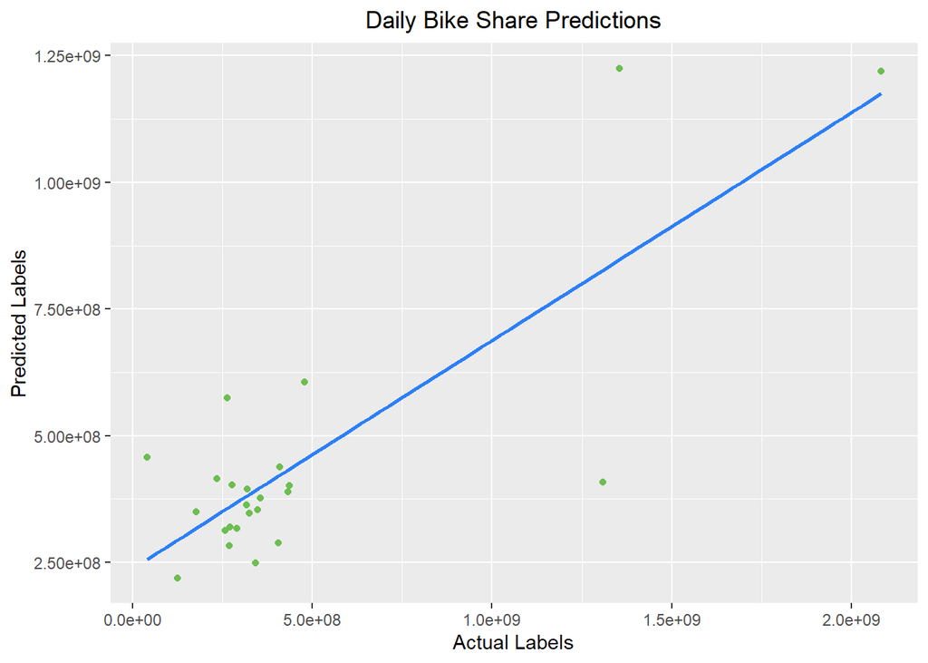

```r
# For reproducibility
set.seed(2056)

# Build a random forest model specification
rf_spec <- rand_forest() %>%
  set_engine('randomForest') %>%
  set_mode('regression')

# Train a random forest model
rf_mod <- rf_spec %>%
  fit(CP ~ ., data = dataTrain)

results_rf <- rf_mod %>%
  augment(new_data = dataTest) %>%
  rename(predictions = .pred)

# Create a metric set
eval_metrics_rf <- metric_set(rmse, rsq)

rf_metrics <- eval_metrics_rf(data = results_rf,
                                  truth = CP,
                                  estimate = predictions)

rf_plt <- results_rf %>%
  ggplot(mapping = aes(x = CP, y = predictions)) +
  geom_point(color = '#6CBE50FF') +
  geom_smooth(method = 'lm', color = '#2B7FF9FF', se = F) +
  ggtitle("Daily Bike Share Predictions") +
  xlab("Actual Labels") +
  ylab("Predicted Labels") +
  theme(plot.title = element_text(hjust = 0.5))

list(rf_metrics[2, ], rf_plt)
```

## 5.2 Modelo LASSO

```
[[1]]
# A tibble: 1 × 3
  .metric .estimator .estimate
  <chr>   <chr>          <dbl>
1 rsq     standard       0.654

[[2]]
```

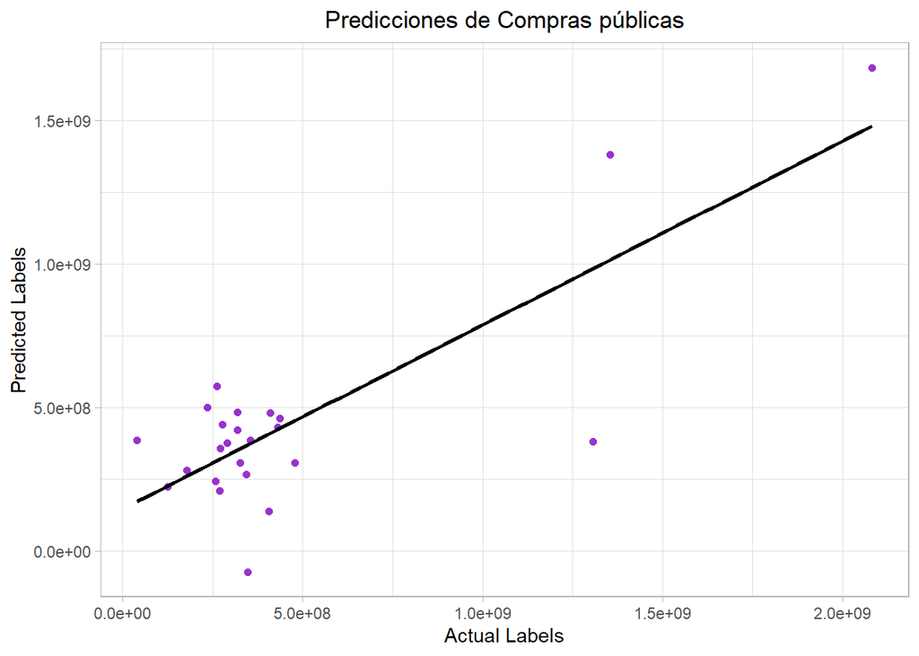

```r
# Build a lasso model
lasso_spec <- linear_reg(
  engine = "glmnet",
  mode = "regression",
  penalty = 1,
  mixture = 1)

# Train
lasso_mod <- lasso_spec %>%
  fit(CP ~ ., data = dataTrain)

results_lasso <- dataTest %>%
  bind_cols(lasso_mod %>% predict(new_data = dataTest) %>%
              rename(predictions = .pred))

eval_metrics <- metric_set(rmse, rsq)
lasso_metrics <- eval_metrics(data = results_lasso,
                                    truth = CP,
                                    estimate = predictions)

theme_set(theme_light())
lasso_plt <- results_lasso %>%
  ggplot(mapping = aes(x = CP, y = predictions)) +
  geom_point(size = 1.6, color = 'darkorchid') +
  geom_smooth(method = 'lm', color = 'black', se = F) +
  ggtitle("Predicciones de Compras públicas") +
  xlab("Actual Labels") +
  ylab("Predicted Labels") +
  theme(plot.title = element_text(hjust = 0.5))

# Return evaluations
list(lasso_metrics[2, ], lasso_plt)
```

## 5.3 Modelo Decision Tree

```
[[1]]
# A tibble: 1 × 3
  .metric .estimator .estimate
  <chr>   <chr>          <dbl>
1 rsq     standard       0.709

[[2]]
```

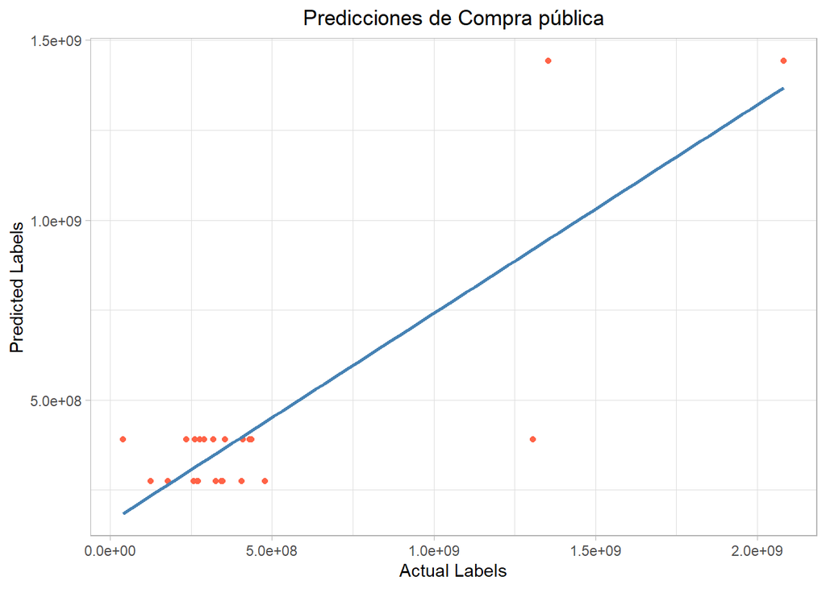

```r
# Build a decision tree
tree_spec <- decision_tree(
  engine = "rpart",
  mode = "regression")

tree_mod <- tree_spec %>%
  fit(CP ~ ., data = dataTrain)

results_tree <- tree_mod %>%
  augment(new_data = dataTest) %>%
  rename(predictions = .pred)

tree_metrics <- eval_metrics(data = results_tree,
                                  truth = CP,
                                  estimate = predictions)

tree_plt <- results_tree %>%
  ggplot(mapping = aes(x = CP, y = predictions)) +
  geom_point(color = 'tomato') +
  geom_smooth(method = 'lm', color = 'steelblue', se = F) +
  ggtitle("Predicciones de Compra pública") +
  xlab("Actual Labels") +
  ylab("Predicted Labels") +
  theme(plot.title = element_text(hjust = 0.5))

# Return evaluations
list(tree_metrics[2, ], tree_plt)
```

## 5.4 Boosting

```r
# Especificamos un recipiente
DataRecipe <- recipe(CP ~ ., data = dataTrain) %>%
  step_normalize(all_numeric_predictors()) %>%
  step_dummy(all_nominal_predictors())

# Hacemos una especificación de modelo ajustable
DataSpec <- boost_tree(trees = 50,
                         tree_depth = tune(),
                         learn_rate = tune()) %>%
  set_engine('xgboost') %>%
  set_mode('regression')

# Agrupe laa receta y la especificación del modelo mediante un WF
boost_workflow <- workflow() %>%
  add_recipe(DataRecipe) %>%
  add_model(DataSpec)
```

- Creamos una grilla de parámetros de ajuste

```r
tree_grid <- grid_regular(tree_depth(), learn_rate(range = c(0.01, 0.3), trans = NULL), levels = 5)
```

- Cross-validation

```r
# 5 fold CV repeated once
DataFolds <- vfold_cv(data = dataTrain, v = 5, repeats = 1)
```

- Procesamiento en paralelo

```r
doParallel::registerDoParallel()

set.seed(2020)
tree_grid <- tune_grid(
  object = boost_workflow,
  resamples = DataFolds,
  grid = tree_grid)
```

- Visualizamos los resultados del tuning

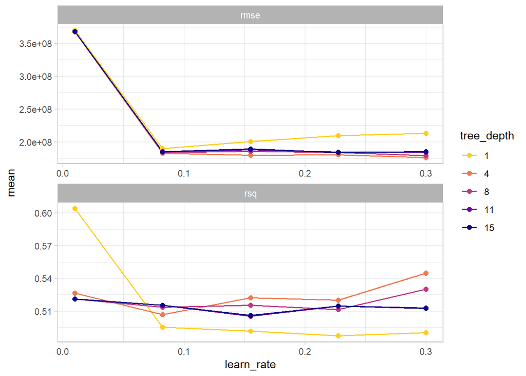

```r
tree_grid %>%
  collect_metrics() %>%
  mutate(tree_depth = factor(tree_depth)) %>%
  ggplot(mapping = aes(x = learn_rate, y = mean,
                       color = tree_depth)) +
  geom_line(size = 0.6) +
  geom_point(size = 2) +
  facet_wrap(~ .metric, scales = 'free', nrow = 2)+
  scale_color_viridis_d(option = "plasma", begin = .9, end = 0)
```

- Selección del mejor iperparámetro

```r
best_tree <- tree_grid %>%
  select_best('rmse')
```

- Finalizar el modelo XGBOOST

```r
# Update workflow
final_wf <- boost_workflow %>%
  finalize_workflow(best_tree)
```

```r
# Último ajuste
final_fit <- final_wf %>%
  last_fit(data_split)
```

- Usamos el modelo entrenado

```r
CP_boost_model <- final_fit$.workflow[[1]]

saveRDS(CP_boost_model, 'CP_boost_model.rds')
```

```r
# Load the model
loaded_model <- readRDS("CP_boost_model.rds")

# Use the model to predict rentals
results_1 <- loaded_model %>%
  augment(dataTest)

XGB_metrics <- eval_metrics(data = results_1,
                                  truth = CP,
                                  estimate = .pred)

XGB_metrics[2, ]
```

```
# A tibble: 1 × 3
  .metric .estimator .estimate
  <chr>   <chr>          <dbl>
1 rsq     standard       0.736
```

# 6 RESULTADOS

De los 4 modelos analizados, se determina que el modelo **Boosting** explica de mejor manera los datos, con una métrica rsq de 0.73.

```
# A tibble: 4 × 6
           m2   Ingr_trib    Gast_SPF    Ofert_M1         CP     .pred
        <dbl>       <dbl>       <dbl>       <dbl>      <dbl>     <dbl>
1 39941031121  900573399. 3269753522. 19250481121 177620766. 146688976
2 65050551395 1063055988. 3241771789. 28252738818 326010401. 298403136
3 66318481206 1075822351. 3429915201. 28673297346 355610226. 396778912
4 67919466538 1113688624. 3341115593. 29428058590 270959855. 277654624
```

# 7 CONCLUSIONES

- El modelo BOOSTING muestra una explicación del 73 % de los datos utilizados, si bien es cierto, aun no se puede considerar a esto como un valor altamente representativo, sin embargo, hay que considerar que los datos obtenidos de la plataforma de Contrataciones de Datos Abiertos, no consideran ciertos procesos de contratación, como por ejemplo las ínfimas cuantías, procedimiento más utilizado por las entidades pertenecientes al sector público, la no incorporación de este proceso si representa un déficit monetario altamente significativo.
- Los modelos realizados pueden ser utilizados y mejorados conforme se vaya generando más información, la importancia de este modelo radica en que, con la ayuda del Machine Learning se pueden tomar decisiones de política monetaria, es decir, si el Gobierno Central prevé obtener más liquidez o en su defecto mayores ingresos tributarios, puede acudir a la contratación pública, considerándola como una herramienta dinamizadora de la economía, permitiéndole tener una guía de cuanto recursos invertir en la contratación pública, hay que considerar que los recursos destinados a la compra pública generan de manera directa e indirecta, cierta liquidez, empleo, aumento de los tributos. Aplicando el *principio Ceteris paribus*, se puede analizar cómo mejorar las variables analizadas en relación a la compra pública.

# 8 RECOMENDACIONES